# Booking.com Ratings Visualisation

Visualising Open Data

```r
library(ggplot2)
library(stringr)
library(ggmap)
library(rworldmap)
library(ggthemes)
library(cowplot)
library(dplyr)
require(scales)
```

## Data

```r
#Load Data
hotel <- read.csv("./Hotel_Reviews.csv")
hotel$Sentiments <- ifelse(hotel$Review_Total_Positive_Word_Counts == 0,"Negative",
                           ifelse(hotel$Review_Total_Negative_Word_Counts == 0, "Positive", "Mixed"))
hotel$Sentiments <- factor(hotel$Sentiments, factor(c('Positive','Mixed', 'Negative')))
hotel <- hotel[!(hotel$Sentiments == "Positive" & hotel$Reviewer_Score < 8), ]
hotel <- hotel[!(hotel$Sentiments == "Mixed" & hotel$Reviewer_Score < 5.5), ]
```

```r
alpha = 1
width = 0.5
size = 1.2
color = c("#08519c", "#3182bd",   "#9ecae1")
```

## Visualisation

```r
box <- ggplot(hotel,aes(x=Sentiments,y=Reviewer_Score, fill=Sentiments)) +
        geom_boxplot(position=position_dodge(2), width=width,alpha=alpha,size = size) +
            theme_fivethirtyeight(base_size = 10, base_family = "sans") +
            theme(axis.title = element_text(),
                axis.title.x = element_text(face = "bold",  size = 18),
                axis.title.y = element_text(face = "bold",  size = 18),
                axis.text.y = element_text(face = "bold", size=12),
                axis.text.x = element_text(face = "bold", size=10),
                axis.line = element_line(colour = "black"),
                plot.title = element_text(size = 20),
                plot.subtitle = element_text(size=16),
                plot.caption = element_text(size = 8, colour = "black",hjust = -0.05, vjust=-2 ),
                legend.position="none") +
                ylab("Reviewer Rating") + xlab("Reviewer's Sentiments") +
                ggtitle('How are Booking.com users rating hotels?') +
                labs(caption = "Jason Liu: www.kaggle.com/jiashenliu/515k-hotel-reviews-data-in-europe",
                subtitle="Distribution of user sentiments across ratings and the proportion of sentiments") +
                scale_fill_manual(values = color)+
                scale_y_continuous(breaks=seq(1, 10, 1), limits = c(1,10)) +
                coord_flip()
```

```r
bar <- ggplot(hotel,aes(Sentiments, y=..count../sum(..count..), fill=Sentiments)) +
          geom_bar(colour="black",size = size, width=width,alpha=alpha)+
          theme_fivethirtyeight(base_size = 10, base_family = "sans") +
          theme(axis.title = element_text(),
                axis.title.x = element_text(face = "bold",  size = 18),
                axis.text.x = element_text(face = "bold", size=10),
                axis.title.y=element_blank(),axis.text.y=element_blank(),
                axis.ticks.y=element_blank(),
                axis.line = element_line(colour = "black"),
                legend.title = element_text(face = "bold",size = 14),
                legend.text = element_text(size = 12 ) ,
                legend.position="none",
                legend.direction = "vertical",
                legend.box = "vertical",
                panel.spacing = unit(1.0, "lines") ,
                plot.margin = margin(0, 2, 0, 1, "cm")) +  ylab("Proportion (%)") +
                scale_y_continuous( labels=percent, breaks = seq(0,10,0.1), limits = c(0,1)) +
                scale_fill_manual(values = color, guide = guide_legend(reverse = TRUE)) +
                coord_flip()
```

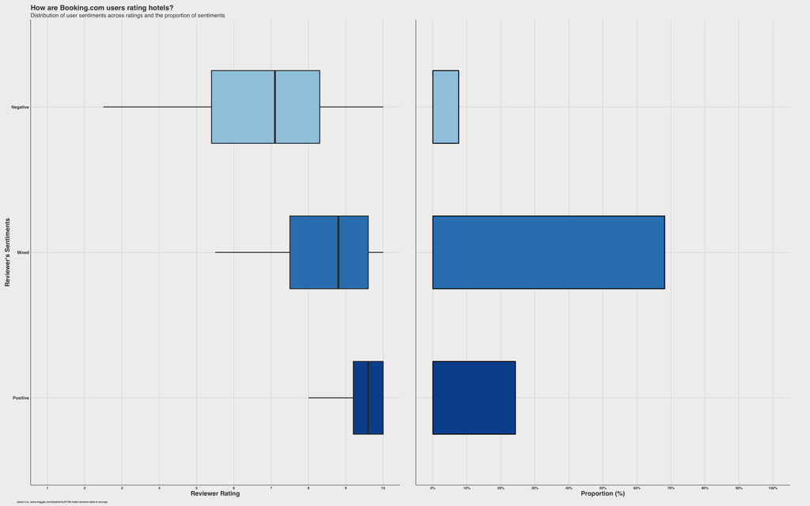

```r
plot_grid(box,bar,ncol=2, align="h", rel_widths = c(4,4), rel_heights = c(3,3))
```

The visualisation is a sample of 512,000 user reviews and ratings from booking.com, a hotel booking website where users can review their accommodation. A user can leave a “Negative” comment and/or a “Positive” comment then leave a rating from 1 to 10. The objective of this visualisation is to interpret user review and rating habits. The data contains the relevant variables to answer this question. Each row is one user’s review. The variables of interest are the negative comments, the positive comments and the final rating. If for instance, the positive comments variables is empty, this indicates only a negative comment was left. If both have been filled out, then it’s a “Mixed” review.

The box plot on the left-hand side shows the distribution of sentiment types across ratings and the bar graph on the right-hand side shows the proportion of the overall sentiment types. The visualisation shows that users are leaving above average ratings when leaving only negative comments, however only negative comments make up a small proportion overall. Positive reviews have a tighter distribution raging from 8-10. Mixed reviews seem to be the most frequent type of sentiment for ratings between 5.5 to 10.